# sirenstock

```python
import numpy as np
import matplotlib.pyplot as plt
import pandas as pd
%matplotlib inline
```

```python
#df = pd.read_csv('sirc-17804_9075_14209_201612_L_M_20170104_171522721.csv',delimiter=';',encoding='latin-1',\
#                 parse_dates=['DCRET','DEFET','DATE_DEB_ETAT_ADM_ET','DEFEN','DCREN'])
df = pd.read_csv('sirc-17804_9075_14209_201612_L_M_20170104_171522721.csv',delimiter=';',encoding='latin-1')
```

```python
df.RNA.replace('NaN',np.nan,inplace=True)
df.head()
```

[output not shown]

```python
df = df.loc[df.RNA.isnull()]
```

```python
df = df[df.NOMEN_LONG.str.contains("COMMUNE ",case=False) == False]
```

```python
df = df[df.NOMEN_LONG.str.contains("association ",case=False) == False]
df = df[df.NOMEN_LONG.str.contains("amicale ",case=False) == False]
df = df[df.NOMEN_LONG.str.contains("departement ",case=False) == False]
df = df[df.NOMEN_LONG.str.contains("prefecture ",case=False) == False]
df = df[df.NOMEN_LONG.str.contains("communal ",case=False) == False]
```

List of (interesting) variables:

- SIREN : firm id
- NIC : internal id of the establishment
- NOMEN_LONG : firm name
- EFETCENT : employees in the establishment (rounded to 100s)
- DEFET : validity date for EFETCENT
- ORIGINE : origin
  - "" Sans objet
  - 1 Création (pour tout type de déclaration)
  - 3 Achat (pour les déclarations non agricoles)
  - 4 Apport (pour les déclarations non agricoles)
  - 6 Prise en location gérance (pour les déclarations
  - non agricoles)
  - 7 Partage (pour les déclarations non agricoles)
  - 8 Reprise (pour les déclarations non agricoles)
  - 9 Autre (pour les déclarations non agricoles)
  - A Reprise globale d'une exploitation (pour les déclarations agricoles)
  - B Poursuite de l'exploitation par le conjoint (pour les déclarations agricoles)
  - C Transfert de propriété (pour les déclarations agricoles)
  - D Apport d'exploitation(s) individuelle(s) (pour les déclarations agricoles)
  - E Reprise totale ou partielle d'exploitation individuelle (déclarations agricoles)
  - F Gérance - mandat
  - NR Non renseigné
- DECRET : creation date for the establishment
- DDEBACT/DATE_DEB_ETAT_ADM_ET : date for beginning of activities
- EFENCENT : nb of employees in firm (100s)
- DEFENCENT : validity date
- DCREN : firm creation date
- TCA: tranche de chiffre d'affaires:
  - "" Non renseignée
  - 0 Moins de 0,5 million d'euros
  - 1 De 0,5 à moins de 1 million d'euros
  - 2 De 1 million à moins de 2 millions d'euros
  - 3 De 2 millions à moins de 5 millions d'euros
  - 4 De 5 millions à moins de 10 millions d' euros
  - 5 De 10 millions à moins de 20 millions d'euros
  - 6 De 20 millions à moins de 50 millions d'euros
  - 7 De 50 millions à moins de 100 millions d'euros
  - 8 De 100 millions à moins de 200 millions d'euros
  - 9 200 millions d'euros ou plus

```python
df=  df[['SIREN','NIC','NOMEN_LONG','EFETCENT','DEFET','ORIGINE','DCRET','DATE_DEB_ETAT_ADM_ET','EFENCENT','DEFEN','DCREN','TCA']]
```

```python
df.head()
```

|  | SIREN | NIC | NOMEN_LONG | EFETCENT | DEFET | ORIGINE | DCRET | DATE_DEB_ETAT_ADM_ET | EFENCENT | DEFEN | DCREN | TCA |
| --- | --- | --- | --- | --- | --- | --- | --- | --- | --- | --- | --- | --- |
| 0 | 325175 | 57 | JANOYER*THIERRY/ | NN | 2014.0 | 1 | 20140107.0 | 20140107.0 | NN | 2014.0 | 20000926.0 | NaN |
| 1 | 5420021 | 56 | ETABLISSEMENTS LUCIEN BIQUEZ | 10 | 2009.0 | 1 | 20091223.0 | 20091223.0 | 10 | 2009.0 | 19540101.0 | NaN |
| 2 | 5420120 | 15 | SOCIETE DES SUCRERIES DU MARQUENTERRE | 3 | 2015.0 | 1 | 19890127.0 | 19890127.0 | 10 | 2015.0 | 19540101.0 | 0.0 |
| 3 | 5420120 | 23 | SOCIETE DES SUCRERIES DU MARQUENTERRE | 0 | 2014.0 | NaN | 19000101.0 | 19000101.0 | 10 | 2015.0 | 19540101.0 | 0.0 |
| 4 | 5420120 | 31 | SOCIETE DES SUCRERIES DU MARQUENTERRE | 6 | 2015.0 | NaN | 19000101.0 | 20080423.0 | 10 | 2015.0 | 19540101.0 | 0.0 |

Clean things up : rename date debut d'activites, change date formats.

```python
df = df.rename(columns={'DATE_DEB_ETAT_ADM_ET':'DDEBACT'})
```

```python
df = df.assign(DCRET=pd.to_datetime(df.DCRET.dropna().astype(int).astype(str), format='%Y%M%d').dt.date)
```

```python
df = df.assign(DCREN=pd.to_datetime(df.DCREN.dropna().astype(int).astype(str), format='%Y%M%d').dt.date)
```

```python
df.head()
```

|  | SIREN | NIC | NOMEN_LONG | EFETCENT | DEFET | ORIGINE | DCRET | DDEBACT | EFENCENT | DEFEN | DCREN | TCA |
| --- | --- | --- | --- | --- | --- | --- | --- | --- | --- | --- | --- | --- |
| 0 | 325175 | 57 | JANOYER*THIERRY/ | NN | 2014.0 | 1 | 2014-01-07 | 20140107.0 | NN | 2014.0 | 2000-01-26 | NaN |
| 1 | 5420021 | 56 | ETABLISSEMENTS LUCIEN BIQUEZ | 10 | 2009.0 | 1 | 2009-01-23 | 20091223.0 | 10 | 2009.0 | 1954-01-01 | NaN |
| 2 | 5420120 | 15 | SOCIETE DES SUCRERIES DU MARQUENTERRE | 3 | 2015.0 | 1 | 1989-01-27 | 19890127.0 | 10 | 2015.0 | 1954-01-01 | 0.0 |
| 3 | 5420120 | 23 | SOCIETE DES SUCRERIES DU MARQUENTERRE | 0 | 2014.0 | NaN | 1900-01-01 | 19000101.0 | 10 | 2015.0 | 1954-01-01 | 0.0 |
| 4 | 5420120 | 31 | SOCIETE DES SUCRERIES DU MARQUENTERRE | 6 | 2015.0 | NaN | 1900-01-01 | 20080423.0 | 10 | 2015.0 | 1954-01-01 | 0.0 |

```python
len(df.SIREN.unique())
```

```
8912504
```

```python
df.EFENCENT.replace('NN',np.nan,inplace=True)
```

```python
df.EFETCENT.replace('NN',np.nan,inplace=True)
df.head()
```

|  | SIREN | NIC | NOMEN_LONG | EFETCENT | DEFET | ORIGINE | DCRET | DDEBACT | EFENCENT | DEFEN | DCREN | TCA |
| --- | --- | --- | --- | --- | --- | --- | --- | --- | --- | --- | --- | --- |
| 0 | 325175 | 57 | JANOYER*THIERRY/ | NaN | 2014.0 | 1 | 2014-01-07 | 20140107.0 | NaN | 2014.0 | 2000-01-26 | NaN |
| 1 | 5420021 | 56 | ETABLISSEMENTS LUCIEN BIQUEZ | 10 | 2009.0 | 1 | 2009-01-23 | 20091223.0 | 10 | 2009.0 | 1954-01-01 | NaN |
| 2 | 5420120 | 15 | SOCIETE DES SUCRERIES DU MARQUENTERRE | 3 | 2015.0 | 1 | 1989-01-27 | 19890127.0 | 10 | 2015.0 | 1954-01-01 | 0.0 |
| 3 | 5420120 | 23 | SOCIETE DES SUCRERIES DU MARQUENTERRE | 0 | 2014.0 | NaN | 1900-01-01 | 19000101.0 | 10 | 2015.0 | 1954-01-01 | 0.0 |
| 4 | 5420120 | 31 | SOCIETE DES SUCRERIES DU MARQUENTERRE | 6 | 2015.0 | NaN | 1900-01-01 | 20080423.0 | 10 | 2015.0 | 1954-01-01 | 0.0 |

```python
df.DDEBACT.replace('nan',np.nan,inplace=True)
```

```python
df.head()
```

|  | SIREN | NIC | NOMEN_LONG | EFETCENT | DEFET | ORIGINE | DCRET | DDEBACT | EFENCENT | DEFEN | DCREN | TCA |
| --- | --- | --- | --- | --- | --- | --- | --- | --- | --- | --- | --- | --- |
| 0 | 325175 | 57 | JANOYER*THIERRY/ | NaN | 2014.0 | 1 | 2014-01-07 | 20140107.0 | NaN | 2014.0 | 2000-01-26 | NaN |
| 1 | 5420021 | 56 | ETABLISSEMENTS LUCIEN BIQUEZ | 10 | 2009.0 | 1 | 2009-01-23 | 20091223.0 | 10 | 2009.0 | 1954-01-01 | NaN |
| 2 | 5420120 | 15 | SOCIETE DES SUCRERIES DU MARQUENTERRE | 3 | 2015.0 | 1 | 1989-01-27 | 19890127.0 | 10 | 2015.0 | 1954-01-01 | 0.0 |
| 3 | 5420120 | 23 | SOCIETE DES SUCRERIES DU MARQUENTERRE | 0 | 2014.0 | NaN | 1900-01-01 | 19000101.0 | 10 | 2015.0 | 1954-01-01 | 0.0 |
| 4 | 5420120 | 31 | SOCIETE DES SUCRERIES DU MARQUENTERRE | 6 | 2015.0 | NaN | 1900-01-01 | 20080423.0 | 10 | 2015.0 | 1954-01-01 | 0.0 |

```python
df.EFENCENT= df.EFENCENT.astype(float)
df.EFETCENT=df.EFETCENT.astype(float)
```

```python
df.head()
```

|  | SIREN | NIC | NOMEN_LONG | EFETCENT | DEFET | ORIGINE | DCRET | DDEBACT | EFENCENT | DEFEN | DCREN | TCA |
| --- | --- | --- | --- | --- | --- | --- | --- | --- | --- | --- | --- | --- |
| 0 | 325175 | 57 | JANOYER*THIERRY/ | NaN | 2014.0 | 1 | 2014-01-07 | 20140107.0 | NaN | 2014.0 | 2000-01-26 | NaN |
| 1 | 5420021 | 56 | ETABLISSEMENTS LUCIEN BIQUEZ | 10.0 | 2009.0 | 1 | 2009-01-23 | 20091223.0 | 10.0 | 2009.0 | 1954-01-01 | NaN |
| 2 | 5420120 | 15 | SOCIETE DES SUCRERIES DU MARQUENTERRE | 3.0 | 2015.0 | 1 | 1989-01-27 | 19890127.0 | 10.0 | 2015.0 | 1954-01-01 | 0.0 |
| 3 | 5420120 | 23 | SOCIETE DES SUCRERIES DU MARQUENTERRE | 0.0 | 2014.0 | NaN | 1900-01-01 | 19000101.0 | 10.0 | 2015.0 | 1954-01-01 | 0.0 |
| 4 | 5420120 | 31 | SOCIETE DES SUCRERIES DU MARQUENTERRE | 6.0 | 2015.0 | NaN | 1900-01-01 | 20080423.0 | 10.0 | 2015.0 | 1954-01-01 | 0.0 |

```python
import datetime
def is_not_date(x):
    if type(x) != datetime.date:
        return True
    return False

df.loc[df.DCRET.apply(lambda x: is_not_date(x))]
```

|  | SIREN | NIC | NOMEN_LONG | EFETCENT | DEFET | ORIGINE | DCRET | DDEBACT | EFENCENT | DEFEN | DCREN | TCA |
| --- | --- | --- | --- | --- | --- | --- | --- | --- | --- | --- | --- | --- |
| 536233 | 315386268 | 33 | EURO INTER HOTELS | NaN | NaN | NaN | NaN | 20071201.0 | 0.0 | 2004.0 | 1979-01-01 | NaN |
| 571748 | 317639276 | 29 | SOCIETE GENERALE DE FABRICATIONS MECANIQUES | NaN | NaN | 1 | NaN | 20110920.0 | 0.0 | 2004.0 | 1993-01-19 | NaN |
| 576205 | 317868081 | 66 | TAXI DU SUD | NaN | NaN | 1 | NaN | 20130913.0 | 0.0 | 2004.0 | 1976-01-01 | NaN |
| 905216 | 332340694 | 22 | PINGET*GERALD/ | NaN | NaN | NaN | NaN | 20100219.0 | 0.0 | 2004.0 | 1983-01-01 | NaN |
| 908275 | 332457282 | 25 | BARALE*FERRIER/MICHELE/ | NaN | NaN | NaN | NaN | 20120101.0 | 0.0 | 2004.0 | 1985-01-01 | NaN |
| 1620128 | 380499400 | 22 | SCI HECT COETERA | NaN | NaN | NaN | NaN | 20081216.0 | 0.0 | 2004.0 | 1991-01-12 | NaN |
| 1638733 | 380930487 | 59 | LY DO INVESTISSEMENTS | NaN | NaN | NaN | NaN | 20090602.0 | 0.0 | 2004.0 | 1990-01-23 | NaN |
| 1721402 | 382933927 | 40 | SARL LA RECLUSIERE | NaN | NaN | NaN | NaN | 20100630.0 | 0.0 | 2004.0 | 1991-01-19 | NaN |
| 1989829 | 391142627 | 28 | DEFRATEL | NaN | NaN | NaN | NaN | 20060323.0 | 0.0 | 2004.0 | 1993-01-10 | NaN |
| 2203342 | 398076257 | 29 | SCI VALENCAY | NaN | NaN | NaN | NaN | 20060630.0 | 0.0 | 2004.0 | 1994-01-30 | NaN |
| 2285793 | 399874361 | 21 | SARL MOUSSU | NaN | NaN | NaN | NaN | 20130724.0 | 0.0 | 2004.0 | 1995-01-03 | NaN |
| 2303139 | 400237665 | 23 | SARL SOCIETE DE MISE EN DEVELOPPEMENT DE LA RE... | NaN | NaN | 1 | NaN | 20070101.0 | 0.0 | 2004.0 | 1995-01-03 | NaN |
| 2308256 | 400351516 | 28 | SCI MAGDO | NaN | NaN | NaN | NaN | 20070101.0 | NaN | NaN | 1994-01-16 | NaN |
| 2354922 | 401396932 | 22 | CANTAGRILL | NaN | NaN | NaN | NaN | 20080112.0 | 0.0 | 2004.0 | 1995-01-09 | NaN |
| 2446806 | 403408347 | 33 | LES TROENES SARL | NaN | NaN | 1 | NaN | 20111225.0 | 0.0 | 2004.0 | 1996-01-11 | NaN |
| 2450136 | 403478332 | 22 | EURL YVINVEST | NaN | NaN | NaN | NaN | 20070930.0 | 0.0 | 2004.0 | 1996-01-22 | NaN |
| 2527310 | 405191370 | 23 | SOCIETE CIVILE DE GESTION | NaN | NaN | NaN | NaN | 20061212.0 | NaN | NaN | 1996-01-02 | NaN |
| 2586498 | 408570042 | 23 | SCI DU PARC | NaN | NaN | NaN | NaN | 20120629.0 | 0.0 | 2004.0 | 1996-01-05 | NaN |
| 2686753 | 410729040 | 23 | SOCIETE CIVILE JUMAUTRET | NaN | NaN | NaN | NaN | 20111121.0 | 0.0 | 2004.0 | 1996-01-20 | NaN |
| 2722582 | 411508377 | 24 | SOURCES | NaN | NaN | NaN | NaN | 20051125.0 | 0.0 | 2004.0 | 1997-01-05 | NaN |
| 2733434 | 411759681 | 25 | FORMI | NaN | NaN | NaN | NaN | 20051110.0 | NaN | NaN | 1997-01-20 | NaN |
| 2739289 | 411888480 | 26 | JMS | NaN | NaN | NaN | NaN | 20090930.0 | 0.0 | 2004.0 | 1997-01-18 | NaN |
| 2815941 | 413517681 | 24 | SCI BREVAL | NaN | NaN | NaN | NaN | 20130810.0 | 0.0 | 2004.0 | 1997-01-07 | NaN |
| 2895142 | 415123116 | 22 | M.G.M. | NaN | NaN | NaN | NaN | 20051125.0 | 0.0 | 2004.0 | 1997-01-22 | NaN |
| 2922557 | 417752599 | 23 | SCI DAPHNEE | NaN | NaN | NaN | NaN | 20130702.0 | 0.0 | 2004.0 | 1998-01-16 | NaN |
| 2929982 | 417890589 | 35 | MSD FRANCE | 1400.0 | 2015.0 | NaN | NaN | 20110701.0 | 1400.0 | 2015.0 | 1998-01-27 | 9.0 |
| 2962073 | 418552691 | 28 | SCI KIM | NaN | NaN | NaN | NaN | 20070101.0 | 0.0 | 2004.0 | 1998-01-28 | NaN |
| 3022174 | 419783279 | 21 | SCI LES MIMOSAS | NaN | NaN | NaN | NaN | 20141204.0 | 0.0 | 2004.0 | 1998-01-05 | NaN |
| 3043855 | 420233959 | 22 | MEYMACIENNE DE SUPERMARCHES | NaN | NaN | 1 | NaN | 20111225.0 | 0.0 | 2004.0 | 1998-01-21 | NaN |
| 3081488 | 421005943 | 20 | SCI TRYD | NaN | NaN | NaN | NaN | 20160720.0 | 0.0 | 2004.0 | 1998-01-03 | NaN |
| ... | ... | ... | ... | ... | ... | ... | ... | ... | ... | ... | ... | ... |
| 10285394 | 822397279 | 24 | CJ'S | NaN | NaN | 3 | NaN | 20161013.0 | NaN | NaN | 2016-01-08 | NaN |
| 10288920 | 822433025 | 27 | SARL LES DELICES DU MEE | NaN | NaN | 3 | NaN | 20161019.0 | NaN | NaN | 2016-01-05 | NaN |
| 10291724 | 822462008 | 27 | L'HYPERBOL | NaN | NaN | NaN | NaN | 20161121.0 | NaN | NaN | 2016-01-27 | NaN |
| 10291779 | 822462578 | 29 | AFLAT | NaN | NaN | 3 | NaN | 20161001.0 | NaN | NaN | 2016-01-12 | NaN |
| 10294775 | 822493334 | 20 | AUTOS BAN SAINT MARTIN | NaN | NaN | 3 | NaN | 20161201.0 | NaN | NaN | 2016-01-06 | NaN |
| 10308390 | 822631784 | 29 | BGS | NaN | NaN | 3 | NaN | 20161116.0 | NaN | NaN | 2016-01-20 | NaN |
| 10314065 | 822689527 | 23 | SAS ATEL | NaN | NaN | 1 | NaN | 20161014.0 | NaN | NaN | 2016-01-22 | NaN |
| 10314949 | 822698676 | 27 | KNG | NaN | NaN | 3 | NaN | 20161102.0 | NaN | NaN | 2016-01-23 | NaN |
| 10321112 | 822760997 | 20 | SARL FILAOS VOYAGES | NaN | NaN | NaN | NaN | 20161219.0 | NaN | NaN | 2016-01-27 | NaN |
| 10322924 | 822779542 | 23 | SSB | NaN | NaN | 3 | NaN | 20160930.0 | NaN | NaN | 2016-01-01 | NaN |
| 10327108 | 822821963 | 29 | F 2 C TENDANCES | NaN | NaN | 1 | NaN | 20161201.0 | NaN | NaN | 2016-01-22 | NaN |
| 10328459 | 822835575 | 25 | SCI HARMONIE | NaN | NaN | NaN | NaN | 20161117.0 | NaN | NaN | 2016-01-29 | NaN |
| 10330031 | 822851390 | 28 | NICOLAS RICHARD | NaN | NaN | 1 | NaN | 20161205.0 | NaN | NaN | 2016-01-29 | NaN |
| 10333672 | 822888533 | 20 | C&B MERIBEL | NaN | NaN | 3 | NaN | 20161013.0 | NaN | NaN | 2016-01-03 | NaN |
| 10334547 | 822897559 | 24 | LES PETITS CISEAUX | NaN | NaN | NaN | NaN | 20161024.0 | NaN | NaN | 2016-01-03 | NaN |
| 10335219 | 822904348 | 23 | RB & ASSOCIES | NaN | NaN | NaN | NaN | 20161212.0 | NaN | NaN | 2016-01-21 | NaN |
| 10335239 | 822904546 | 22 | CYRCOH | NaN | NaN | NaN | NaN | 20161128.0 | NaN | NaN | 2016-01-27 | NaN |
| 10335271 | 822904868 | 20 | FABG DISTRIBUTION | NaN | NaN | 6 | NaN | 20161011.0 | NaN | NaN | 2016-01-04 | NaN |
| 10338728 | 822940029 | 25 | CREPE TOUCH | NaN | NaN | NaN | NaN | 20161102.0 | NaN | NaN | 2016-01-04 | NaN |
| 10340510 | 822958252 | 22 | ANI COIFFURE ET RETOUCHERIE | NaN | NaN | NaN | NaN | 20161208.0 | NaN | NaN | 2016-01-06 | NaN |
| 10343174 | 822985446 | 27 | VIGI PREVENTION | NaN | NaN | NaN | NaN | 20161128.0 | NaN | NaN | 2016-01-10 | NaN |
| 10343335 | 822987111 | 25 | BOULANGERIE JULIE ET OLIVIER | NaN | NaN | 3 | NaN | 20161027.0 | NaN | NaN | 2016-01-07 | NaN |
| 10370780 | 823266390 | 25 | TOLLET SARL | NaN | NaN | 1 | NaN | 20161031.0 | NaN | NaN | 2016-01-11 | NaN |
| 10371631 | 823274956 | 23 | TRIMEL | NaN | NaN | 6 | NaN | 20161201.0 | NaN | NaN | 2016-01-21 | NaN |
| 10377746 | 823337274 | 26 | CASTOR FRANCE | NaN | NaN | NaN | NaN | 20161216.0 | NaN | NaN | 2016-01-21 | NaN |
| 10390780 | 823469218 | 23 | GINKO | NaN | NaN | 6 | NaN | 20161216.0 | NaN | NaN | 2016-01-26 | NaN |
| 10402313 | 823586110 | 20 | LE PETIT BAIN | NaN | NaN | NaN | NaN | 20161206.0 | NaN | NaN | 2016-01-08 | NaN |
| 10409708 | 823660683 | 25 | F3S PREVENTION | NaN | NaN | NaN | NaN | 20161201.0 | NaN | NaN | 2016-01-12 | NaN |
| 10432847 | 823893508 | 23 | JPSA | NaN | NaN | NaN | NaN | 20161212.0 | NaN | NaN | 2016-01-23 | NaN |
| 10440747 | 823972872 | 27 | 9 PCJ | NaN | NaN | NaN | NaN | 20161201.0 | NaN | NaN | 2016-01-28 | NaN |

4271 rows × 12 columns

```python
df.DCRET = df.DCRET.astype(pd.datetime)
```

```python
df.DCRET= pd.to_datetime(df.DCRET)
```

```python
df.DCREN=pd.to_datetime(df.DCREN)
```

```python
def cleaner(x):
    try:
        new_x = float(x)
    except Exception:
        new_x = np.nan
    return new_x

df.ORIGINE = df.ORIGINE.apply(lambda x: cleaner(x))
df.TCA = df.TCA.apply(lambda x: cleaner(x))
```

```python
df.head()
```

|  | SIREN | NIC | NOMEN_LONG | EFETCENT | DEFET | ORIGINE | DCRET | DDEBACT | EFENCENT | DEFEN | DCREN | TCA |
| --- | --- | --- | --- | --- | --- | --- | --- | --- | --- | --- | --- | --- |
| 0 | 325175 | 57 | JANOYER*THIERRY/ | NaN | 2014.0 | 1.0 | 2014-01-07 | 20140107.0 | NaN | 2014.0 | 2000-01-26 | NaN |
| 1 | 5420021 | 56 | ETABLISSEMENTS LUCIEN BIQUEZ | 10.0 | 2009.0 | 1.0 | 2009-01-23 | 20091223.0 | 10.0 | 2009.0 | 1954-01-01 | NaN |
| 2 | 5420120 | 15 | SOCIETE DES SUCRERIES DU MARQUENTERRE | 3.0 | 2015.0 | 1.0 | 1989-01-27 | 19890127.0 | 10.0 | 2015.0 | 1954-01-01 | 0.0 |
| 3 | 5420120 | 23 | SOCIETE DES SUCRERIES DU MARQUENTERRE | 0.0 | 2014.0 | NaN | 1900-01-01 | 19000101.0 | 10.0 | 2015.0 | 1954-01-01 | 0.0 |
| 4 | 5420120 | 31 | SOCIETE DES SUCRERIES DU MARQUENTERRE | 6.0 | 2015.0 | NaN | 1900-01-01 | 20080423.0 | 10.0 | 2015.0 | 1954-01-01 | 0.0 |

```python
df.loc[df.DDEBACT==31020803.0]
df.set_value(5881888,'DDEBACT',20130803.0).head()
```

|  | SIREN | NIC | NOMEN_LONG | EFETCENT | DEFET | ORIGINE | DCRET | DDEBACT | EFENCENT | DEFEN | DCREN | TCA |
| --- | --- | --- | --- | --- | --- | --- | --- | --- | --- | --- | --- | --- |
| 0 | 325175 | 57 | JANOYER*THIERRY/ | NaN | 2014.0 | 1.0 | 2014-01-07 | 20140107.0 | NaN | 2014.0 | 2000-01-26 | NaN |
| 1 | 5420021 | 56 | ETABLISSEMENTS LUCIEN BIQUEZ | 10.0 | 2009.0 | 1.0 | 2009-01-23 | 20091223.0 | 10.0 | 2009.0 | 1954-01-01 | NaN |
| 2 | 5420120 | 15 | SOCIETE DES SUCRERIES DU MARQUENTERRE | 3.0 | 2015.0 | 1.0 | 1989-01-27 | 19890127.0 | 10.0 | 2015.0 | 1954-01-01 | 0.0 |
| 3 | 5420120 | 23 | SOCIETE DES SUCRERIES DU MARQUENTERRE | 0.0 | 2014.0 | NaN | 1900-01-01 | 19000101.0 | 10.0 | 2015.0 | 1954-01-01 | 0.0 |
| 4 | 5420120 | 31 | SOCIETE DES SUCRERIES DU MARQUENTERRE | 6.0 | 2015.0 | NaN | 1900-01-01 | 20080423.0 | 10.0 | 2015.0 | 1954-01-01 | 0.0 |

```python
df.DDEBACT=pd.to_datetime(df.DDEBACT, format='%Y%m%d.0')
```

```python
df.NOMEN_LONG = df.NOMEN_LONG.str.encode('utf-8')
```

Plot histogram of sizes (number of employees)

```python
df.to_hdf('sirenstock.h5',key='key_to_store',format='table',mode='w')
```

```python
list(df)
```

```
[u'SIREN',
 u'NIC',
 u'NOMEN_LONG',
 u'EFETCENT',
 u'DEFET',
 u'ORIGINE',
 u'DCRET',
 'DDEBACT',
 u'EFENCENT',
 u'DEFEN',
 u'DCREN',
 u'TCA']
```

```python
df.NOMEN_LONG.describe()
```

```
count      9869121
unique     7519906
top       LA POSTE
freq         11252
Name: NOMEN_LONG, dtype: object
```

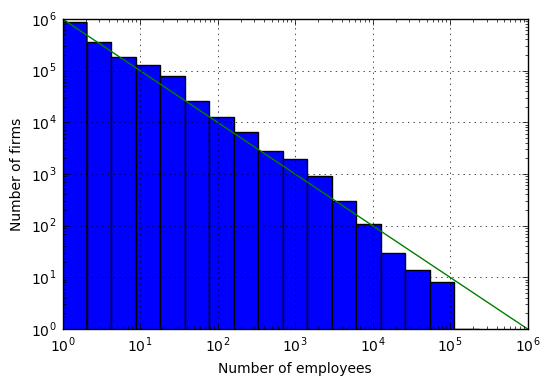

```python
df.groupby('SIREN').first().EFENCENT.hist(bins=np.logspace(0,6,20))
s = np.logspace(0,6,20)
plt.plot(s,1e6*s**(-1.))
plt.yscale('log')
plt.xscale('log')
plt.xlabel('Number of employees')
plt.ylabel('Number of firms')
```

cumulative plot

```python
a = df.loc[df.EFENCENT.notnull()].groupby('SIREN').first().EFENCENT
```

```python
sizes = a.values
```

```python
Ns = np.logspace(1,6,40)
Pns = [np.sum(sizes>n) for n in Ns]
```

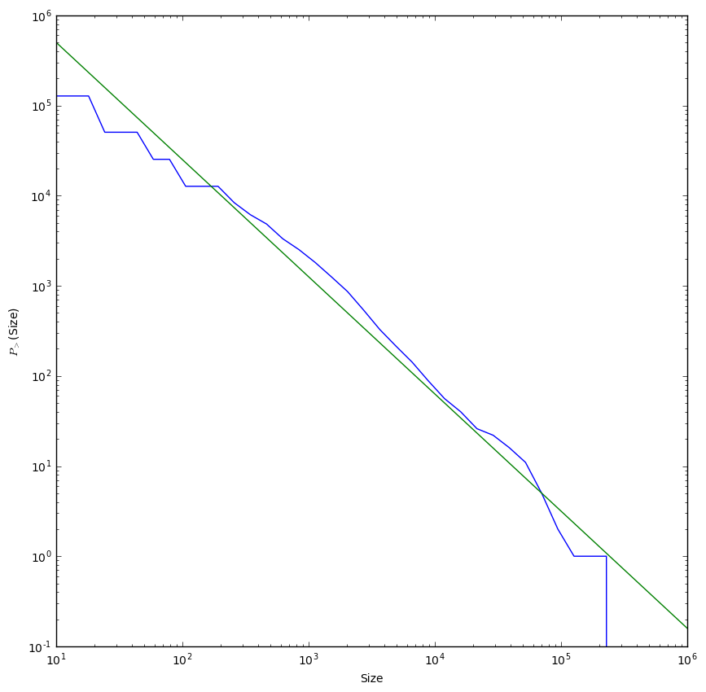

```python
plt.figure(figsize=(10,10))
plt.plot(Ns,Pns)
plt.plot(Ns,1e7*Ns**(-(1.3)))
plt.xlabel('Size')
plt.ylabel('$P_>$(Size)')
plt.yscale('log')
plt.xscale('log')
```

Compute firm ages

```python
df.AGE = pd.to_datetime('1 JAN 2017').date() - df.DCREN
```

```python
df = df.assign(AGE=pd.to_datetime('1 JAN 2017').date() - df.DCREN)
df = df.assign(AGE_IN_DAYS=df.AGE.astype(int) / 1e9 / 3600 / 24)
```

```python
df.head()
```

|  | SIREN | NIC | NOMEN_LONG | EFETCENT | DEFET | ORIGINE | DCRET | DDEBACT | EFENCENT | DEFEN | DCREN | TCA | AGE_IN_DAYS | AGE |
| --- | --- | --- | --- | --- | --- | --- | --- | --- | --- | --- | --- | --- | --- | --- |
| 0 | 325175 | 57 | JANOYER*THIERRY/ | NaN | 2014.0 | 1 | 2014-01-07 | 20140107.0 | NaN | 2014.0 | 2000-01-26 | NaN | 6185.0 | 6185 days |
| 1 | 5420021 | 56 | ETABLISSEMENTS LUCIEN BIQUEZ | 10.0 | 2009.0 | 1 | 2009-01-23 | 20091223.0 | 10.0 | 2009.0 | 1954-01-01 | NaN | 23011.0 | 23011 days |
| 2 | 5420120 | 15 | SOCIETE DES SUCRERIES DU MARQUENTERRE | 3.0 | 2015.0 | 1 | 1989-01-27 | 19890127.0 | 10.0 | 2015.0 | 1954-01-01 | 0.0 | 23011.0 | 23011 days |
| 3 | 5420120 | 23 | SOCIETE DES SUCRERIES DU MARQUENTERRE | 0.0 | 2014.0 | NaN | 1900-01-01 | 19000101.0 | 10.0 | 2015.0 | 1954-01-01 | 0.0 | 23011.0 | 23011 days |
| 4 | 5420120 | 31 | SOCIETE DES SUCRERIES DU MARQUENTERRE | 6.0 | 2015.0 | NaN | 1900-01-01 | 20080423.0 | 10.0 | 2015.0 | 1954-01-01 | 0.0 | 23011.0 | 23011 days |

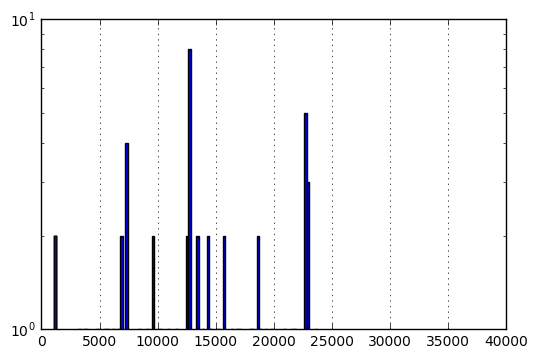

```python
df.loc[np.logical_and(df.EFENCENT>10000,df.AGE_IN_DAYS<40000)].groupby('SIREN').first().AGE_IN_DAYS.hist(bins=100)
plt.xlim(0,4e4)
plt.yscale('log')
```

```python
df.loc[np.logical_and(df.EFENCENT>10000,df.AGE_IN_DAYS<5000)]
```

|  | SIREN | NIC | NOMEN_LONG | EFETCENT | DEFET | ORIGINE | DCRET | DDEBACT | EFENCENT | DEFEN | DCREN | TCA | AGE_IN_DAYS | AGE |
| --- | --- | --- | --- | --- | --- | --- | --- | --- | --- | --- | --- | --- | --- | --- |
| 92015 | 130005481 | 10 | POLE EMPLOI | 1000.0 | 2015.0 | 1 | 2008-01-19 | 20081219.0 | 54300.0 | 2015.0 | 2008-01-19 | NaN | 3270.0 | 3270 days |
| 92016 | 130005481 | 28 | POLE EMPLOI | 20.0 | 2015.0 | 8 | 2008-01-19 | 20081219.0 | 54300.0 | 2015.0 | 2008-01-19 | NaN | 3270.0 | 3270 days |
| 92017 | 130005481 | 192 | POLE EMPLOI | 20.0 | 2015.0 | 8 | 2008-01-19 | 20081219.0 | 54300.0 | 2015.0 | 2008-01-19 | NaN | 3270.0 | 3270 days |
| 92018 | 130005481 | 218 | POLE EMPLOI | 100.0 | 2015.0 | 8 | 2008-01-19 | 20081219.0 | 54300.0 | 2015.0 | 2008-01-19 | NaN | 3270.0 | 3270 days |
| 92019 | 130005481 | 234 | POLE EMPLOI | 20.0 | 2015.0 | 8 | 2008-01-19 | 20081219.0 | 54300.0 | 2015.0 | 2008-01-19 | NaN | 3270.0 | 3270 days |
| 92020 | 130005481 | 283 | POLE EMPLOI | 20.0 | 2015.0 | 8 | 2008-01-19 | 20081219.0 | 54300.0 | 2015.0 | 2008-01-19 | NaN | 3270.0 | 3270 days |
| 92021 | 130005481 | 309 | POLE EMPLOI | 20.0 | 2015.0 | 8 | 2008-01-19 | 20081219.0 | 54300.0 | 2015.0 | 2008-01-19 | NaN | 3270.0 | 3270 days |
| 92022 | 130005481 | 325 | POLE EMPLOI | 50.0 | 2015.0 | 8 | 2008-01-19 | 20081219.0 | 54300.0 | 2015.0 | 2008-01-19 | NaN | 3270.0 | 3270 days |
| 92023 | 130005481 | 333 | POLE EMPLOI | NaN | NaN | 8 | 2008-01-19 | 20081219.0 | 54300.0 | 2015.0 | 2008-01-19 | NaN | 3270.0 | 3270 days |
| 92024 | 130005481 | 341 | POLE EMPLOI | 20.0 | 2015.0 | 8 | 2008-01-19 | 20081219.0 | 54300.0 | 2015.0 | 2008-01-19 | NaN | 3270.0 | 3270 days |
| 92025 | 130005481 | 358 | POLE EMPLOI | 10.0 | 2015.0 | 8 | 2008-01-19 | 20081219.0 | 54300.0 | 2015.0 | 2008-01-19 | NaN | 3270.0 | 3270 days |
| 92026 | 130005481 | 374 | POLE EMPLOI | 20.0 | 2015.0 | 8 | 2008-01-19 | 20081219.0 | 54300.0 | 2015.0 | 2008-01-19 | NaN | 3270.0 | 3270 days |
| 92027 | 130005481 | 457 | POLE EMPLOI | 50.0 | 2015.0 | 8 | 2008-01-19 | 20081219.0 | 54300.0 | 2015.0 | 2008-01-19 | NaN | 3270.0 | 3270 days |
| 92028 | 130005481 | 465 | POLE EMPLOI | 20.0 | 2015.0 | 8 | 2008-01-19 | 20081219.0 | 54300.0 | 2015.0 | 2008-01-19 | NaN | 3270.0 | 3270 days |
| 92029 | 130005481 | 549 | POLE EMPLOI | 20.0 | 2015.0 | 8 | 2008-01-19 | 20081219.0 | 54300.0 | 2015.0 | 2008-01-19 | NaN | 3270.0 | 3270 days |
| 92030 | 130005481 | 614 | POLE EMPLOI | 20.0 | 2015.0 | 8 | 2008-01-19 | 20081219.0 | 54300.0 | 2015.0 | 2008-01-19 | NaN | 3270.0 | 3270 days |
| 92031 | 130005481 | 622 | POLE EMPLOI | 50.0 | 2015.0 | 8 | 2008-01-19 | 20081219.0 | 54300.0 | 2015.0 | 2008-01-19 | NaN | 3270.0 | 3270 days |
| 92032 | 130005481 | 630 | POLE EMPLOI | 0.0 | 2012.0 | 8 | 2008-01-19 | 20081219.0 | 54300.0 | 2015.0 | 2008-01-19 | NaN | 3270.0 | 3270 days |
| 92033 | 130005481 | 655 | POLE EMPLOI | 20.0 | 2015.0 | 8 | 2008-01-19 | 20081219.0 | 54300.0 | 2015.0 | 2008-01-19 | NaN | 3270.0 | 3270 days |
| 92034 | 130005481 | 663 | POLE EMPLOI | 20.0 | 2015.0 | 8 | 2008-01-19 | 20081219.0 | 54300.0 | 2015.0 | 2008-01-19 | NaN | 3270.0 | 3270 days |
| 92035 | 130005481 | 697 | POLE EMPLOI | 50.0 | 2015.0 | 8 | 2008-01-19 | 20081219.0 | 54300.0 | 2015.0 | 2008-01-19 | NaN | 3270.0 | 3270 days |
| 92036 | 130005481 | 705 | POLE EMPLOI | 50.0 | 2015.0 | 8 | 2008-01-19 | 20081219.0 | 54300.0 | 2015.0 | 2008-01-19 | NaN | 3270.0 | 3270 days |
| 92037 | 130005481 | 754 | POLE EMPLOI | 20.0 | 2015.0 | 8 | 2008-01-19 | 20081219.0 | 54300.0 | 2015.0 | 2008-01-19 | NaN | 3270.0 | 3270 days |
| 92038 | 130005481 | 762 | POLE EMPLOI | 20.0 | 2015.0 | 8 | 2008-01-19 | 20081219.0 | 54300.0 | 2015.0 | 2008-01-19 | NaN | 3270.0 | 3270 days |
| 92039 | 130005481 | 770 | POLE EMPLOI | 20.0 | 2015.0 | 8 | 2008-01-19 | 20081219.0 | 54300.0 | 2015.0 | 2008-01-19 | NaN | 3270.0 | 3270 days |
| 92040 | 130005481 | 796 | POLE EMPLOI | 20.0 | 2015.0 | 8 | 2008-01-19 | 20081219.0 | 54300.0 | 2015.0 | 2008-01-19 | NaN | 3270.0 | 3270 days |
| 92041 | 130005481 | 804 | POLE EMPLOI | 50.0 | 2015.0 | 8 | 2008-01-19 | 20081219.0 | 54300.0 | 2015.0 | 2008-01-19 | NaN | 3270.0 | 3270 days |
| 92042 | 130005481 | 838 | POLE EMPLOI | 20.0 | 2015.0 | 8 | 2008-01-19 | 20081219.0 | 54300.0 | 2015.0 | 2008-01-19 | NaN | 3270.0 | 3270 days |
| 92043 | 130005481 | 879 | POLE EMPLOI | 100.0 | 2015.0 | 8 | 2008-01-19 | 20081219.0 | 54300.0 | 2015.0 | 2008-01-19 | NaN | 3270.0 | 3270 days |
| 92044 | 130005481 | 937 | POLE EMPLOI | 20.0 | 2015.0 | 8 | 2008-01-19 | 20081219.0 | 54300.0 | 2015.0 | 2008-01-19 | NaN | 3270.0 | 3270 days |
| ... | ... | ... | ... | ... | ... | ... | ... | ... | ... | ... | ... | ... | ... | ... |
| 9182972 | 808332670 | 5384 | SNCF | 1.0 | 2015.0 | 1 | 2015-01-01 | 20151001.0 | 11700.0 | 2015.0 | 2014-01-01 | NaN | 1096.0 | 1096 days |
| 9182973 | 808332670 | 5392 | SNCF | 6.0 | 2015.0 | 1 | 2015-01-01 | 20151001.0 | 11700.0 | 2015.0 | 2014-01-01 | NaN | 1096.0 | 1096 days |
| 9182974 | 808332670 | 5400 | SNCF | NaN | 2015.0 | 1 | 2015-01-01 | 20151001.0 | 11700.0 | 2015.0 | 2014-01-01 | NaN | 1096.0 | 1096 days |
| 9182975 | 808332670 | 5418 | SNCF | 200.0 | 2015.0 | 1 | 2015-01-01 | 20151001.0 | 11700.0 | 2015.0 | 2014-01-01 | NaN | 1096.0 | 1096 days |
| 9182976 | 808332670 | 5426 | SNCF | NaN | 2015.0 | 1 | 2015-01-01 | 20151001.0 | 11700.0 | 2015.0 | 2014-01-01 | NaN | 1096.0 | 1096 days |
| 9182977 | 808332670 | 5434 | SNCF | NaN | 2015.0 | 1 | 2015-01-01 | 20151001.0 | 11700.0 | 2015.0 | 2014-01-01 | NaN | 1096.0 | 1096 days |
| 9182978 | 808332670 | 5442 | SNCF | NaN | 2016.0 | 1 | 2016-01-01 | 20160101.0 | 11700.0 | 2015.0 | 2014-01-01 | NaN | 1096.0 | 1096 days |
| 9182979 | 808332670 | 5459 | SNCF | NaN | 2016.0 | 1 | 2016-01-01 | 20160101.0 | 11700.0 | 2015.0 | 2014-01-01 | NaN | 1096.0 | 1096 days |
| 9182980 | 808332670 | 5467 | SNCF | NaN | 2016.0 | 1 | 2016-01-01 | 20160101.0 | 11700.0 | 2015.0 | 2014-01-01 | NaN | 1096.0 | 1096 days |
| 9182981 | 808332670 | 5475 | SNCF | NaN | 2016.0 | 1 | 2016-01-01 | 20160101.0 | 11700.0 | 2015.0 | 2014-01-01 | NaN | 1096.0 | 1096 days |
| 9182982 | 808332670 | 5483 | SNCF | NaN | 2016.0 | 1 | 2016-01-01 | 20160101.0 | 11700.0 | 2015.0 | 2014-01-01 | NaN | 1096.0 | 1096 days |
| 9182983 | 808332670 | 5491 | SNCF | NaN | 2016.0 | 1 | 2016-01-01 | 20160101.0 | 11700.0 | 2015.0 | 2014-01-01 | NaN | 1096.0 | 1096 days |
| 9182984 | 808332670 | 5509 | SNCF | NaN | 2016.0 | 1 | 2016-01-01 | 20160101.0 | 11700.0 | 2015.0 | 2014-01-01 | NaN | 1096.0 | 1096 days |
| 9182985 | 808332670 | 5517 | SNCF | NaN | 2016.0 | 1 | 2016-01-01 | 20160101.0 | 11700.0 | 2015.0 | 2014-01-01 | NaN | 1096.0 | 1096 days |
| 9182986 | 808332670 | 5525 | SNCF | NaN | 2016.0 | 1 | 2016-01-01 | 20160101.0 | 11700.0 | 2015.0 | 2014-01-01 | NaN | 1096.0 | 1096 days |
| 9182987 | 808332670 | 5533 | SNCF | NaN | 2016.0 | 1 | 2016-01-01 | 20160101.0 | 11700.0 | 2015.0 | 2014-01-01 | NaN | 1096.0 | 1096 days |
| 9182988 | 808332670 | 5541 | SNCF | NaN | 2016.0 | 1 | 2016-01-01 | 20160301.0 | 11700.0 | 2015.0 | 2014-01-01 | NaN | 1096.0 | 1096 days |
| 9182989 | 808332670 | 5558 | SNCF | NaN | 2016.0 | 1 | 2016-01-01 | 20160301.0 | 11700.0 | 2015.0 | 2014-01-01 | NaN | 1096.0 | 1096 days |
| 9182990 | 808332670 | 5566 | SNCF | NaN | 2016.0 | 1 | 2016-01-01 | 20160301.0 | 11700.0 | 2015.0 | 2014-01-01 | NaN | 1096.0 | 1096 days |
| 9182991 | 808332670 | 5574 | SNCF | NaN | 2016.0 | 1 | 2016-01-01 | 20160401.0 | 11700.0 | 2015.0 | 2014-01-01 | NaN | 1096.0 | 1096 days |
| 9182992 | 808332670 | 5582 | SNCF | NaN | 2016.0 | 1 | 2016-01-01 | 20160401.0 | 11700.0 | 2015.0 | 2014-01-01 | NaN | 1096.0 | 1096 days |
| 9182993 | 808332670 | 5590 | SNCF | NaN | 2016.0 | 1 | 2016-01-01 | 20160401.0 | 11700.0 | 2015.0 | 2014-01-01 | NaN | 1096.0 | 1096 days |
| 9182994 | 808332670 | 5608 | SNCF | NaN | 2016.0 | 1 | 2016-01-01 | 20160601.0 | 11700.0 | 2015.0 | 2014-01-01 | NaN | 1096.0 | 1096 days |
| 9182995 | 808332670 | 5616 | SNCF | NaN | 2016.0 | 1 | 2016-01-01 | 20160601.0 | 11700.0 | 2015.0 | 2014-01-01 | NaN | 1096.0 | 1096 days |
| 9182996 | 808332670 | 5624 | SNCF | NaN | 2016.0 | 1 | 2016-01-01 | 20160701.0 | 11700.0 | 2015.0 | 2014-01-01 | NaN | 1096.0 | 1096 days |
| 9182997 | 808332670 | 5632 | SNCF | NaN | 2016.0 | 1 | 2016-01-01 | 20160801.0 | 11700.0 | 2015.0 | 2014-01-01 | NaN | 1096.0 | 1096 days |
| 9182998 | 808332670 | 5640 | SNCF | NaN | 2016.0 | 1 | 2016-01-01 | 20160801.0 | 11700.0 | 2015.0 | 2014-01-01 | NaN | 1096.0 | 1096 days |
| 9182999 | 808332670 | 5657 | SNCF | NaN | 2016.0 | 1 | 2016-01-01 | 20161101.0 | 11700.0 | 2015.0 | 2014-01-01 | NaN | 1096.0 | 1096 days |
| 9183000 | 808332670 | 5665 | SNCF | NaN | 2017.0 | 1 | 2017-01-01 | 20170101.0 | 11700.0 | 2015.0 | 2014-01-01 | NaN | 1096.0 | 1096 days |
| 9183001 | 808332670 | 5673 | SNCF | NaN | 2017.0 | 1 | 2017-01-01 | 20170101.0 | 11700.0 | 2015.0 | 2014-01-01 | NaN | 1096.0 | 1096 days |

2502 rows × 14 columns

```python
df.loc[df.AGE_IN_DAYS>40000]
```

|  | SIREN | NIC | NOMEN_LONG | EFETCENT | DEFET | ORIGINE | DCRET | DDEBACT | EFENCENT | DEFEN | DCREN | TCA | AGE_IN_DAYS | AGE |
| --- | --- | --- | --- | --- | --- | --- | --- | --- | --- | --- | --- | --- | --- | --- |
| 25 | 5540661 | 21 | HONNORAT*AVON/MARIE ANTOINETTE/ | 0.0 | 2004.0 | NaN | 1900-01-01 | 19000101.0 | 0.0 | 2004.0 | 1900-01-01 | NaN | 42734.0 | 42734 days |
| 35 | 5580501 | 12 | SOCIETE DES GLACIERES ET FRIGORIFIQUES DE SAIN... | 10.0 | 2007.0 | 1 | 1986-01-25 | 19861225.0 | 20.0 | 2007.0 | 1900-01-01 | 0.0 | 42734.0 | 42734 days |
| 36 | 5580501 | 46 | SOCIETE DES GLACIERES ET FRIGORIFIQUES DE SAIN... | 0.0 | 2004.0 | 9 | 1996-01-01 | 19960501.0 | 20.0 | 2007.0 | 1900-01-01 | 0.0 | 42734.0 | 42734 days |
| 173 | 6040034 | 16 | BOERI*SPITALIER/ALINE/ | 0.0 | 2004.0 | NaN | 1900-01-01 | 19000101.0 | 0.0 | 2004.0 | 1900-01-01 | NaN | 42734.0 | 42734 days |
| 174 | 6040034 | 24 | BOERI*SPITALIER/ALINE/ | 0.0 | 2004.0 | 1 | 1990-01-01 | 19900101.0 | 0.0 | 2004.0 | 1900-01-01 | NaN | 42734.0 | 42734 days |
| 258 | 6350102 | 15 | SA IMMOB AGRIC DOM GRDE FUSTE | 0.0 | 2004.0 | 1 | 1900-01-01 | 19000101.0 | 0.0 | 2004.0 | 1900-01-01 | NaN | 42734.0 | 42734 days |
| 268 | 6410120 | 23 | MEHAY*GUY/ | 1.0 | 2015.0 | 1 | 1900-01-01 | 19000101.0 | 1.0 | 2015.0 | 1900-01-01 | NaN | 42734.0 | 42734 days |
| 310 | 6574586 | 27 | BOMAL*JEAN YVES MARIE/ | 0.0 | 2004.0 | 1 | 1900-01-01 | 19000101.0 | 0.0 | 2004.0 | 1900-01-01 | NaN | 42734.0 | 42734 days |
| 311 | 6574586 | 35 | BOMAL*JEAN YVES MARIE/ | NaN | 2007.0 | 1 | 2007-01-01 | 20070901.0 | 0.0 | 2004.0 | 1900-01-01 | NaN | 42734.0 | 42734 days |
| 383 | 6871438 | 39 | RAMBAUD*ALBERT FERNAND GUSTAVE/ | 0.0 | 2004.0 | 1 | 1986-01-20 | 19860620.0 | 0.0 | 2004.0 | 1900-01-01 | NaN | 42734.0 | 42734 days |
| 412 | 6970602 | 22 | CZIMMERMAN*MADELEINE/ | 0.0 | 2004.0 | 1 | 1900-01-01 | 19000101.0 | 0.0 | 2004.0 | 1900-01-01 | NaN | 42734.0 | 42734 days |
| 414 | 6971022 | 30 | BELLANGER*ROBERT/ | NaN | 2009.0 | 9 | 2009-01-01 | 20090401.0 | NaN | 2009.0 | 1900-01-01 | NaN | 42734.0 | 42734 days |
| 415 | 6971022 | 48 | BELLANGER*ROBERT/ | NaN | 2012.0 | 1 | 2012-01-10 | 20120810.0 | NaN | 2012.0 | 1900-01-01 | NaN | 42734.0 | 42734 days |
| 422 | 6973606 | 38 | LACHAUD*DOMINIQUE MAURICE/ | 0.0 | 2004.0 | 1 | 1989-01-01 | 19890101.0 | 0.0 | 2015.0 | 1900-01-01 | NaN | 42734.0 | 42734 days |
| 423 | 6973606 | 46 | LACHAUD*DOMINIQUE MAURICE/ | 0.0 | 2015.0 | 9 | 2001-01-23 | 20010523.0 | 0.0 | 2015.0 | 1900-01-01 | NaN | 42734.0 | 42734 days |
| 428 | 6974349 | 26 | LEHOURS*ROBERT/ | 0.0 | 2004.0 | 9 | 1900-01-01 | 19000101.0 | 0.0 | 2004.0 | 1900-01-01 | NaN | 42734.0 | 42734 days |
| 435 | 6980478 | 17 | FONCIERE GIROUETTE | 0.0 | 2004.0 | NaN | 1900-01-01 | 19000101.0 | 0.0 | 2004.0 | 1900-01-01 | NaN | 42734.0 | 42734 days |
| 507 | 7140163 | 28 | DESPLANS*GUY/ | NaN | 2008.0 | 1 | 2008-01-13 | 20080513.0 | NaN | 2008.0 | 1900-01-01 | NaN | 42734.0 | 42734 days |
| 558 | 7242290 | 59 | COQUILLAT*ANNIE/ | 0.0 | 2014.0 | 1 | 2014-01-15 | 20140415.0 | 0.0 | 2014.0 | 1900-01-01 | NaN | 42734.0 | 42734 days |
| 565 | 7270929 | 57 | CONAN*ANDRE ROBERT VICTOR/ | 0.0 | 2004.0 | 9 | 1996-01-01 | 19960101.0 | 0.0 | 2004.0 | 1900-01-01 | NaN | 42734.0 | 42734 days |
| 566 | 7271026 | 36 | POTIER*DOMINIQUE/ | 0.0 | 2004.0 | 1 | 1995-01-15 | 19951115.0 | 0.0 | 2007.0 | 1900-01-01 | NaN | 42734.0 | 42734 days |
| 579 | 7272941 | 27 | NASLIN*JEAN PIERRE/ | NaN | 2016.0 | 1 | 2016-01-01 | 20160801.0 | NaN | 2016.0 | 1900-01-01 | NaN | 42734.0 | 42734 days |
| 596 | 7280852 | 18 | ALLARD INDUSTRIES | 0.0 | 2004.0 | NaN | 1900-01-01 | 19000101.0 | 0.0 | 2004.0 | 1900-01-01 | NaN | 42734.0 | 42734 days |
| 639 | 7371255 | 22 | LE RUYET*BERNARD JEAN/ | NaN | NaN | NR | 2009-01-12 | 20091012.0 | NaN | NaN | 1900-01-01 | NaN | 42734.0 | 42734 days |
| 1171 | 9717695 | 28 | SCI DU PONT VOLTAIRE | 0.0 | 2004.0 | 9 | 2003-01-10 | 20030710.0 | 0.0 | 2004.0 | 1900-01-01 | NaN | 42734.0 | 42734 days |
| 4706 | 15850894 | 21 | SOC CIVILE PARTICULIERE ARIEL | 0.0 | 2004.0 | 1 | 1989-01-29 | 19890329.0 | 0.0 | 2004.0 | 1900-01-01 | NaN | 42734.0 | 42734 days |
| 4807 | 15944192 | 28 | LEHMANN*EDGAR/ | 0.0 | 2004.0 | NaN | 1900-01-01 | 19000101.0 | 0.0 | 2004.0 | 1900-01-01 | NaN | 42734.0 | 42734 days |
| 4814 | 15950082 | 48 | GPT BOISEMENT AMELIORATION FORESTIERS | 1.0 | 2008.0 | 1 | 1987-01-25 | 19871225.0 | 1.0 | 2008.0 | 1900-01-01 | NaN | 42734.0 | 42734 days |
| 4817 | 15950603 | 17 | ASSO IMMOBILIERE DE LA RUE TURGOT | 0.0 | 2005.0 | NaN | 1900-01-01 | 19000101.0 | 0.0 | 2005.0 | 1900-01-01 | NaN | 42734.0 | 42734 days |
| 4833 | 16050726 | 13 | PARC EXPOS ET CONGRES DE DIJON | 20.0 | 2015.0 | NaN | 1900-01-01 | 19000101.0 | 20.0 | 2015.0 | 1900-01-01 | 4.0 | 42734.0 | 42734 days |
| ... | ... | ... | ... | ... | ... | ... | ... | ... | ... | ... | ... | ... | ... | ... |
| 10537184 | 997566005 | 10 | LA MIROITERIE MODERNE | 10.0 | 2015.0 | 8 | 1900-01-01 | 19000101.0 | 10.0 | 2015.0 | 1900-01-01 | NaN | 42734.0 | 42734 days |
| 10537185 | 997566005 | 28 | LA MIROITERIE MODERNE | 0.0 | 2005.0 | 1 | 1983-01-01 | 19830201.0 | 10.0 | 2015.0 | 1900-01-01 | NaN | 42734.0 | 42734 days |
| 10537192 | 997566815 | 12 | CHAUSSURES MARCEL | 0.0 | 2012.0 | 8 | 1900-01-01 | 19000101.0 | 0.0 | 2012.0 | 1900-01-01 | NaN | 42734.0 | 42734 days |
| 10537203 | 997596713 | 47 | SARL KOMPONG SEILA | 3.0 | 2015.0 | 1 | 1900-01-01 | 19000101.0 | 3.0 | 2015.0 | 1900-01-01 | NaN | 42734.0 | 42734 days |
| 10537224 | 997655618 | 20 | MATERIAUX DE BORAN | NaN | 2013.0 | 1 | 2013-01-10 | 20130610.0 | 0.0 | 2004.0 | 1900-01-01 | NaN | 42734.0 | 42734 days |
| 10537241 | 997719307 | 24 | A. PERMASSE ET FILS | 0.0 | 2004.0 | NaN | 1900-01-01 | 19000101.0 | 0.0 | 2004.0 | 1900-01-01 | NaN | 42734.0 | 42734 days |
| 10537282 | 997838008 | 32 | POLYFORMATIQUE | 0.0 | 2004.0 | 3 | 1991-01-01 | 19910401.0 | 0.0 | 2004.0 | 1900-01-01 | NaN | 42734.0 | 42734 days |
| 10537283 | 997838008 | 40 | POLYFORMATIQUE | NaN | NaN | 1 | 1993-01-01 | 19930601.0 | NaN | NaN | 1900-01-01 | NaN | 42734.0 | 42734 days |
| 10537284 | 997838008 | 57 | POLYFORMATIQUE | NaN | 1996.0 | 1 | 1996-01-01 | 19960201.0 | NaN | 1996.0 | 1900-01-01 | NaN | 42734.0 | 42734 days |
| 10537292 | 997868419 | 42 | LES STUDIOS DE SAINT NOM | 0.0 | 2004.0 | 9 | 2001-01-01 | 20010701.0 | 0.0 | 2004.0 | 1900-01-01 | NaN | 42734.0 | 42734 days |
| 10537359 | 998145601 | 14 | GEORGES K | 0.0 | 2015.0 | 1 | 1900-01-01 | 19000101.0 | 0.0 | 2015.0 | 1900-01-01 | NaN | 42734.0 | 42734 days |
| 10537379 | 998219422 | 16 | PROMOGIL | 100.0 | 2015.0 | 1 | 1900-01-01 | 19000101.0 | 100.0 | 2015.0 | 1900-01-01 | 4.0 | 42734.0 | 42734 days |
| 10537380 | 998219422 | 24 | PROMOGIL | 1.0 | 2015.0 | 1 | 2000-01-01 | 20001101.0 | 100.0 | 2015.0 | 1900-01-01 | 4.0 | 42734.0 | 42734 days |
| 10537452 | 998378913 | 86 | C.P.I.I. | NaN | NaN | 1 | 2015-01-01 | 20150701.0 | 0.0 | 2006.0 | 1900-01-01 | NaN | 42734.0 | 42734 days |
| 10537520 | 998620926 | 35 | SARL DOMEAU CONCEPT | 3.0 | 2015.0 | 9 | 1991-01-12 | 19910612.0 | 3.0 | 2015.0 | 1900-01-01 | NaN | 42734.0 | 42734 days |
| 10537524 | 998640304 | 15 | SOC ECONOMIE MIXTE DE L'ARC DE SEINE | 6.0 | 2015.0 | NaN | 1900-01-01 | 19000101.0 | 6.0 | 2015.0 | 1900-01-01 | 5.0 | 42734.0 | 42734 days |
| 10537527 | 998640817 | 24 | SEVIA | NaN | 1999.0 | 1 | 1999-01-01 | 19991201.0 | NaN | 1999.0 | 1900-01-01 | NaN | 42734.0 | 42734 days |
| 10537528 | 998640817 | 32 | SEVIA | 0.0 | 2004.0 | 9 | 1999-01-25 | 19991025.0 | 0.0 | 2004.0 | 1900-01-01 | NaN | 42734.0 | 42734 days |
| 10537529 | 998650113 | 41 | MONTAGE CABLAGE ELECTRONIQUE DIFFUSION | 3.0 | 2015.0 | 1 | 2014-01-27 | 20140527.0 | 3.0 | 2015.0 | 1900-01-01 | NaN | 42734.0 | 42734 days |
| 10537533 | 998660708 | 194 | GXS | NaN | NaN | 1 | 1979-01-01 | 19790901.0 | 20.0 | 2015.0 | 1900-01-01 | 5.0 | 42734.0 | 42734 days |
| 10537534 | 998660708 | 202 | GXS | NaN | NaN | 1 | 1983-01-15 | 19830315.0 | 20.0 | 2015.0 | 1900-01-01 | 5.0 | 42734.0 | 42734 days |
| 10537535 | 998660708 | 228 | GXS | 20.0 | 2015.0 | 1 | 2014-01-01 | 20140701.0 | 20.0 | 2015.0 | 1900-01-01 | 5.0 | 42734.0 | 42734 days |
| 10537552 | 998774103 | 35 | LE BASQUE BONDISSANT | 20.0 | 2015.0 | 9 | 2002-01-01 | 20021101.0 | 50.0 | 2015.0 | 1900-01-01 | 4.0 | 42734.0 | 42734 days |
| 10537553 | 998774103 | 68 | LE BASQUE BONDISSANT | NaN | 2006.0 | 9 | 2006-01-01 | 20060101.0 | 50.0 | 2015.0 | 1900-01-01 | 4.0 | 42734.0 | 42734 days |
| 10537554 | 998774103 | 76 | LE BASQUE BONDISSANT | NaN | 2006.0 | 9 | 2006-01-01 | 20060101.0 | 50.0 | 2015.0 | 1900-01-01 | 4.0 | 42734.0 | 42734 days |
| 10537555 | 998774103 | 92 | LE BASQUE BONDISSANT | 20.0 | 2015.0 | 6 | 2007-01-01 | 20070101.0 | 50.0 | 2015.0 | 1900-01-01 | 4.0 | 42734.0 | 42734 days |
| 10537556 | 998774103 | 100 | LE BASQUE BONDISSANT | NaN | 2007.0 | 9 | 2007-01-01 | 20070101.0 | 50.0 | 2015.0 | 1900-01-01 | 4.0 | 42734.0 | 42734 days |
| 10538408 | 999990005 | 38 | STEF | 200.0 | 2015.0 | 9 | 1993-01-01 | 19930701.0 | 200.0 | 2015.0 | 1900-01-01 | 5.0 | 42734.0 | 42734 days |
| 10538409 | 999990005 | 137 | STEF | 50.0 | 2007.0 | 4 | 1996-01-19 | 19961219.0 | 200.0 | 2015.0 | 1900-01-01 | 5.0 | 42734.0 | 42734 days |
| 10538413 | 999990120 | 19 | CAISSE D'AMORTISSEMENT POUR L'ACIER | 0.0 | 2004.0 | 1 | 1900-01-01 | 19000101.0 | 0.0 | 2004.0 | 1900-01-01 | NaN | 42734.0 | 42734 days |

164721 rows × 14 columns